# Rozwiązania do zadań z lab 12

Przesiewanie modeli i optymalizacja bayesowska

Author

Dariusz Majerek

Published

May 25, 2026

```r
library(tidymodels)
library(modeldata)
library(workflowsets)
library(rules)
```

## Zadanie 1. Przesiewanie wielu workflowów

Pracujemy na danych `car_prices`. Cena jest dodatnia i prawostronnie skośna, więc modelujemy `log(Price)`. Taka skala ogranicza wpływ najdroższych samochodów i sprawia, że błąd modelu ma interpretację bliższą błędowi względnemu.

```r
set.seed(2026)

car_data <- car_prices %>%
  mutate(Price = log(Price))

car_split <- initial_split(car_data, prop = 0.8, strata = Price)
car_train <- training(car_split)
car_test <- testing(car_split)

set.seed(2026)
car_folds <- vfold_cv(car_train, v = 5, strata = Price)
```

Definiujemy cztery warianty preprocessingu. Pierwszy wariant przekazuje predyktory prawie bez zmian, drugi skaluje predyktory, trzeci usuwa silną redundancję, a czwarty dodaje proste cechy inżynierskie.

```r
car_vars <- workflow_variables(
  outcomes = Price,
  predictors = everything()
)

car_rec_scaled <- recipe(Price ~ ., data = car_train) %>%
  step_zv(all_predictors()) %>%
  step_normalize(all_numeric_predictors())

car_rec_corr <- recipe(Price ~ ., data = car_train) %>%
  step_zv(all_predictors()) %>%
  step_normalize(all_numeric_predictors()) %>%
  step_corr(all_numeric_predictors(), threshold = 0.90)

car_rec_features <- recipe(Price ~ ., data = car_train) %>%
  step_mutate(
    mileage_years = Mileage / 12000,
    luxury_score = Cruise + Sound + Leather,
    doors_per_cylinder = Doors / Cylinder
  ) %>%
  step_log(Mileage, offset = 1) %>%
  step_zv(all_predictors()) %>%
  step_normalize(all_numeric_predictors())
```

Wybieramy cztery rodziny modeli: MARS, SVM z jądrem radialnym, las losowy oraz Cubist. Parametry ustawiamy na rozsądne wartości początkowe; celem zadania jest przesiewanie wielu workflowów, a nie jeszcze pełne strojenie każdego modelu.

```r
mars_spec <- mars(num_terms = 25, prod_degree = 2) %>%
  set_engine("earth") %>%
  set_mode("regression")

svm_spec <- svm_rbf(cost = 1, rbf_sigma = 0.01) %>%
  set_engine("kernlab") %>%
  set_mode("regression")

forest_spec <- rand_forest(trees = 200, min_n = 8) %>%
  set_engine("ranger") %>%
  set_mode("regression")

cubist_spec <- cubist_rules(committees = 10, neighbors = 5) %>%
  set_engine("Cubist") %>%
  set_mode("regression")
```

Tworzymy pełny zestaw workflowów: cztery preprocessingi razy cztery modele.

```r
car_workflows <- workflow_set(
  preproc = list(
    raw = car_vars,
    scaled = car_rec_scaled,
    corr = car_rec_corr,
    features = car_rec_features
  ),
  models = list(
    mars = mars_spec,
    svm = svm_spec,
    forest = forest_spec,
    cubist = cubist_spec
  ),
  cross = TRUE
)

car_workflows
```

```
# A workflow set/tibble: 16 × 4
   wflow_id        info             option    result
   <chr>           <list>           <list>    <list>
 1 raw_mars        <tibble [1 × 4]> <opts[0]> <list [0]>
 2 raw_svm         <tibble [1 × 4]> <opts[0]> <list [0]>
 3 raw_forest      <tibble [1 × 4]> <opts[0]> <list [0]>
 4 raw_cubist      <tibble [1 × 4]> <opts[0]> <list [0]>
 5 scaled_mars     <tibble [1 × 4]> <opts[0]> <list [0]>
 6 scaled_svm      <tibble [1 × 4]> <opts[0]> <list [0]>
 7 scaled_forest   <tibble [1 × 4]> <opts[0]> <list [0]>
 8 scaled_cubist   <tibble [1 × 4]> <opts[0]> <list [0]>
 9 corr_mars       <tibble [1 × 4]> <opts[0]> <list [0]>
10 corr_svm        <tibble [1 × 4]> <opts[0]> <list [0]>
11 corr_forest     <tibble [1 × 4]> <opts[0]> <list [0]>
12 corr_cubist     <tibble [1 × 4]> <opts[0]> <list [0]>
13 features_mars   <tibble [1 × 4]> <opts[0]> <list [0]>
14 features_svm    <tibble [1 × 4]> <opts[0]> <list [0]>
15 features_forest <tibble [1 × 4]> <opts[0]> <list [0]>
16 features_cubist <tibble [1 × 4]> <opts[0]> <list [0]>
```

Uruchamiamy resampling dla wszystkich workflowów na tych samych foldach.

```r
set.seed(2026)

car_res <- workflow_map(
  car_workflows,
  "fit_resamples",
  resamples = car_folds,
  metrics = metric_set(rmse, mae, rsq),
  control = control_resamples(save_pred = TRUE),
  verbose = FALSE
)
```

Ranking według `rmse`:

```r
car_metrics <- collect_metrics(car_res)

car_ranking <- car_metrics %>%
  filter(.metric == "rmse") %>%
  arrange(mean)

car_ranking %>%
  select(wflow_id, mean, std_err, n)
```

```
# A tibble: 16 × 4
   wflow_id          mean std_err     n
   <chr>            <dbl>   <dbl> <int>
 1 features_cubist 0.0925 0.00348     5
 2 scaled_cubist   0.0933 0.00379     5
 3 corr_cubist     0.0933 0.00379     5
 4 raw_cubist      0.0934 0.00401     5
 5 raw_mars        0.0988 0.00390     5
 6 scaled_mars     0.0992 0.00362     5
 7 corr_mars       0.0992 0.00362     5
 8 raw_svm         0.1000 0.00500     5
 9 scaled_svm      0.1000 0.00500     5
10 corr_svm        0.1000 0.00500     5
11 features_forest 0.101  0.00447     5
12 features_svm    0.101  0.00472     5
13 features_mars   0.101  0.00401     5
14 raw_forest      0.109  0.00496     5
15 scaled_forest   0.109  0.00496     5
16 corr_forest     0.109  0.00496     5
```

Stabilność wyników między foldami:

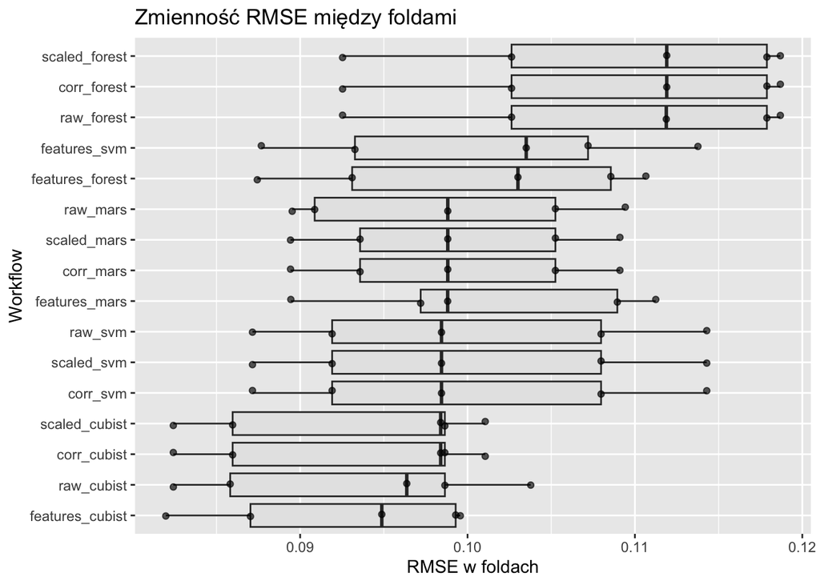

```r
car_fold_rmse <- car_res %>%
  collect_metrics(summarize = FALSE) %>%
  filter(.metric == "rmse")

car_fold_rmse %>%
  ggplot(aes(x = reorder(wflow_id, .estimate, median), y = .estimate)) +
  geom_boxplot(fill = "grey90") +
  geom_point(alpha = 0.65, position = position_jitter(width = 0.08)) +
  coord_flip() +
  labs(
    x = "Workflow",
    y = "RMSE w foldach",
    title = "Zmienność RMSE między foldami"
  )
```

Porównujemy najlepszy workflow z trzema kolejnymi konkurentami. Test jest sparowany, ponieważ wszystkie workflowy były oceniane na tych samych foldach.

```r
best_car_wflow <- car_ranking$wflow_id[1]
car_competitors <- car_ranking$wflow_id[2:4]

car_tests <- purrr::map_dfr(car_competitors, function(comp_id) {
  wide <- car_fold_rmse %>%
    filter(wflow_id %in% c(best_car_wflow, comp_id)) %>%
    select(id, wflow_id, .estimate) %>%
    pivot_wider(names_from = wflow_id, values_from = .estimate)

  test <- t.test(
    wide[[comp_id]],
    wide[[best_car_wflow]],
    paired = TRUE,
    alternative = "greater"
  )

  tibble(
    best = best_car_wflow,
    competitor = comp_id,
    mean_rmse_difference = mean(wide[[comp_id]] - wide[[best_car_wflow]]),
    p_value = test$p.value
  )
})

car_tests
```

```
# A tibble: 3 × 4
  best            competitor    mean_rmse_difference p_value
  <chr>           <chr>                        <dbl>   <dbl>
1 features_cubist scaled_cubist             0.000749   0.207
2 features_cubist corr_cubist               0.000749   0.207
3 features_cubist raw_cubist                0.000859   0.210
```

Dodatnia różnica oznacza, że konkurent ma większy błąd niż najlepszy workflow. Jeżeli `p-value` jest małe, przewaga najlepszego wariantu jest stabilna na foldach.

Finalny workflow dopasowujemy do całego zbioru treningowego i oceniamy na danych testowych.

```r
final_car_wf <- car_workflows %>%
  extract_workflow(best_car_wflow)

final_car_fit <- fit(final_car_wf, data = car_train)

car_test_pred <- car_test %>%
  select(Price) %>%
  bind_cols(predict(final_car_fit, new_data = car_test))

metric_set(rmse, mae, rsq)(
  car_test_pred,
  truth = Price,
  estimate = .pred
)
```

```
# A tibble: 3 × 3
  .metric .estimator .estimate
  <chr>   <chr>          <dbl>
1 rmse    standard      0.0924
2 mae     standard      0.0695
3 rsq     standard      0.950
```

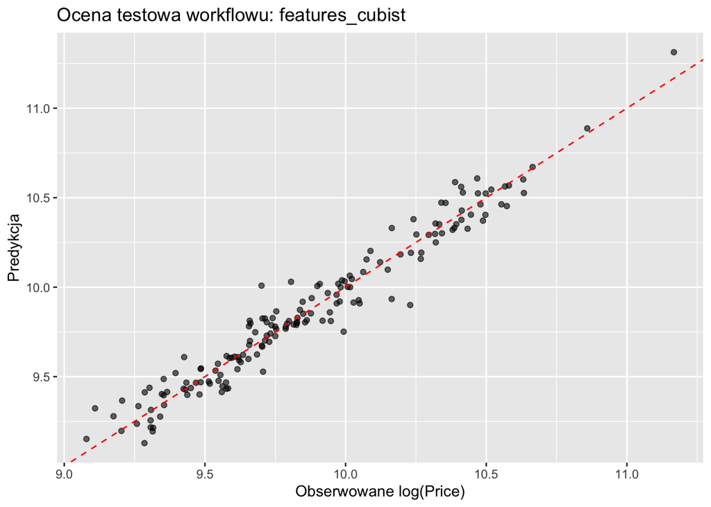

```r
car_test_pred %>%
  ggplot(aes(x = Price, y = .pred)) +
  geom_point(alpha = 0.6) +
  geom_abline(lty = 2, color = "red") +
  labs(
    x = "Obserwowane log(Price)",
    y = "Predykcja",
    title = paste("Ocena testowa workflowu:", best_car_wflow)
  )
```

Jeżeli wyniki testowe są zbliżone do wyników z resamplingu, przesiewanie workflowów nie doprowadziło do wyraźnego przeuczenia procedury wyboru.

## Zadanie 2. Optymalizacja bayesowska

```r
library(finetune)
```

Przygotowujemy dane `ad_data`. Klasa `"Impaired"` zostaje ustawiona jako klasa pozytywna, aby `roc_auc` dotyczyło rozpoznawania przypadków zaburzenia.

```r
set.seed(2026)

ad_model_data <- ad_data %>%
  drop_na() %>%
  mutate(Class = forcats::fct_relevel(Class, "Impaired"))

ad_model_data %>%
  count(Class)
```

```
# A tibble: 2 × 2
  Class        n
  <fct>    <int>
1 Impaired    91
2 Control    242
```

```r
ad_split <- initial_split(ad_model_data, prop = 0.75, strata = Class)
ad_train <- training(ad_split)
ad_test <- testing(ad_split)

set.seed(2026)
ad_folds <- vfold_cv(ad_train, v = 5, strata = Class)
```

Preprocessing koduje zmienną `Genotype`, usuwa predyktory bez zmienności oraz ogranicza nadmiar silnie skorelowanych markerów.

```r
ad_rec <- recipe(Class ~ ., data = ad_train) %>%
  step_dummy(all_nominal_predictors()) %>%
  step_zv(all_predictors()) %>%
  step_corr(all_numeric_predictors(), threshold = 0.90)
```

Definiujemy model boosted trees z czterema hiperparametrami do optymalizacji.

```r
xgb_spec <- boost_tree(
  trees = tune(),
  tree_depth = tune(),
  learn_rate = tune(),
  min_n = tune(),
  loss_reduction = 0,
  sample_size = 0.8
) %>%
  set_engine("xgboost", nthread = 1) %>%
  set_mode("classification")

ad_wf <- workflow() %>%
  add_recipe(ad_rec) %>%
  add_model(xgb_spec)
```

Ustalamy zakresy parametrów. `learn_rate` jest przeszukiwany w skali logarytmicznej.

```r
ad_params <- ad_wf %>%
  extract_parameter_set_dials() %>%
  update(
    trees = trees(c(50L, 150L)),
    tree_depth = tree_depth(c(2L, 6L)),
    learn_rate = learn_rate(c(-3, -1)),
    min_n = min_n(c(2L, 20L))
  )

ad_params
```

[output not shown]

Najpierw tworzymy niewielki plan wypełniający przestrzeń i oceniamy go przez resampling. Te wyniki będą punktem startowym dla modelu procesu gaussowskiego używanego przez optymalizację bayesowską.

```r
set.seed(2026)

ad_initial_grid <- grid_space_filling(ad_params, size = 8)
ad_initial_grid
```

```
# A tibble: 8 × 4
  trees min_n tree_depth learn_rate
  <int> <int>      <int>      <dbl>
1    50    17          4    0.00373
2    64     2          4    0.0139
3    78    12          2    0.1
4    92     7          2    0.00193
5   107    14          6    0.0518
6   121     9          5    0.001
7   135    20          3    0.00720
8   150     4          3    0.0268
```

```r
set.seed(2026)

ad_initial <- tune_grid(
  ad_wf,
  resamples = ad_folds,
  grid = ad_initial_grid,
  metrics = metric_set(roc_auc, accuracy),
  control = control_grid(save_pred = TRUE)
)

show_best(ad_initial, metric = "roc_auc", n = 5)
```

```
# A tibble: 5 × 10
  trees min_n tree_depth learn_rate .metric .estimator  mean     n std_err
  <int> <int>      <int>      <dbl> <chr>   <chr>      <dbl> <int>   <dbl>
1   150     4          3    0.0268  roc_auc binary     0.852     5 0.0173
2    78    12          2    0.1     roc_auc binary     0.824     5 0.0142
3    64     2          4    0.0139  roc_auc binary     0.823     5 0.00788
4   107    14          6    0.0518  roc_auc binary     0.793     5 0.0171
5    92     7          2    0.00193 roc_auc binary     0.781     5 0.00605
# ℹ 1 more variable: .config <chr>
```

Optymalizacja bayesowska używa wyników początkowych, aby wskazywać kolejne kombinacje hiperparametrów z dobrym kompromisem między eksploracją i eksploatacją.

```r
set.seed(2026)

ad_bayes <- tune_bayes(
  ad_wf,
  resamples = ad_folds,
  initial = ad_initial,
  iter = 6,
  param_info = ad_params,
  metrics = metric_set(roc_auc, accuracy),
  control = control_bayes(verbose = FALSE, no_improve = 5)
)
```

Najlepsze konfiguracje po optymalizacji:

```r
show_best(ad_bayes, metric = "roc_auc", n = 8)
```

```
# A tibble: 8 × 11
  trees min_n tree_depth learn_rate .metric .estimator  mean     n std_err
  <int> <int>      <int>      <dbl> <chr>   <chr>      <dbl> <int>   <dbl>
1    90     8          5     0.0979 roc_auc binary     0.861     5 0.00985
2   128     7          5     0.0996 roc_auc binary     0.859     5 0.0148
3    51     9          3     0.0994 roc_auc binary     0.856     5 0.0104
4   150     4          3     0.0268 roc_auc binary     0.852     5 0.0173
5    72     4          5     0.0991 roc_auc binary     0.845     5 0.0224
6   144     3          4     0.0904 roc_auc binary     0.837     5 0.0215
7    78    12          2     0.1    roc_auc binary     0.824     5 0.0142
8    64     2          4     0.0139 roc_auc binary     0.823     5 0.00788
# ℹ 2 more variables: .config <chr>, .iter <int>
```

Przebieg optymalizacji:

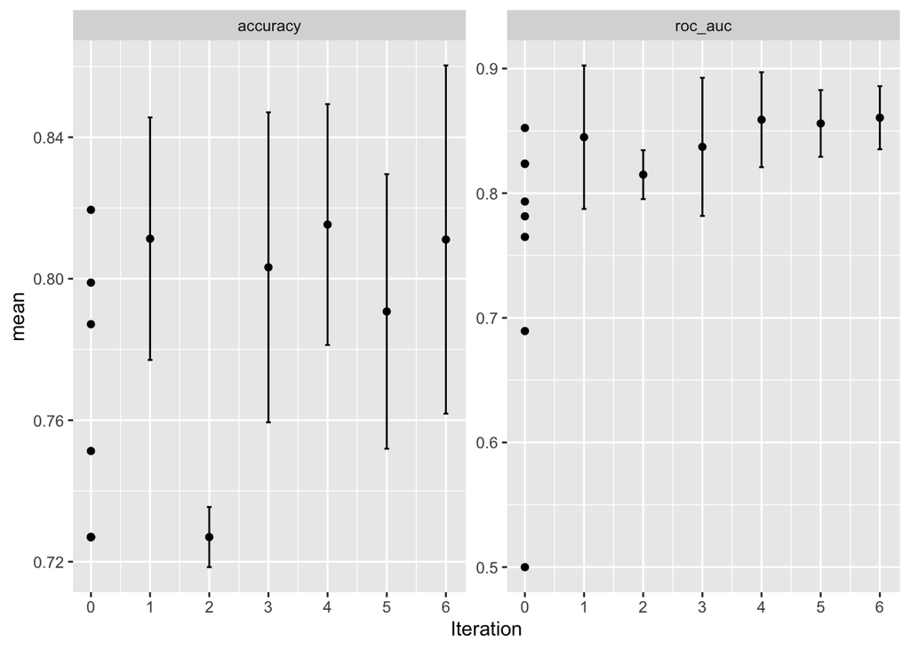

```r
autoplot(ad_bayes, type = "performance")
```

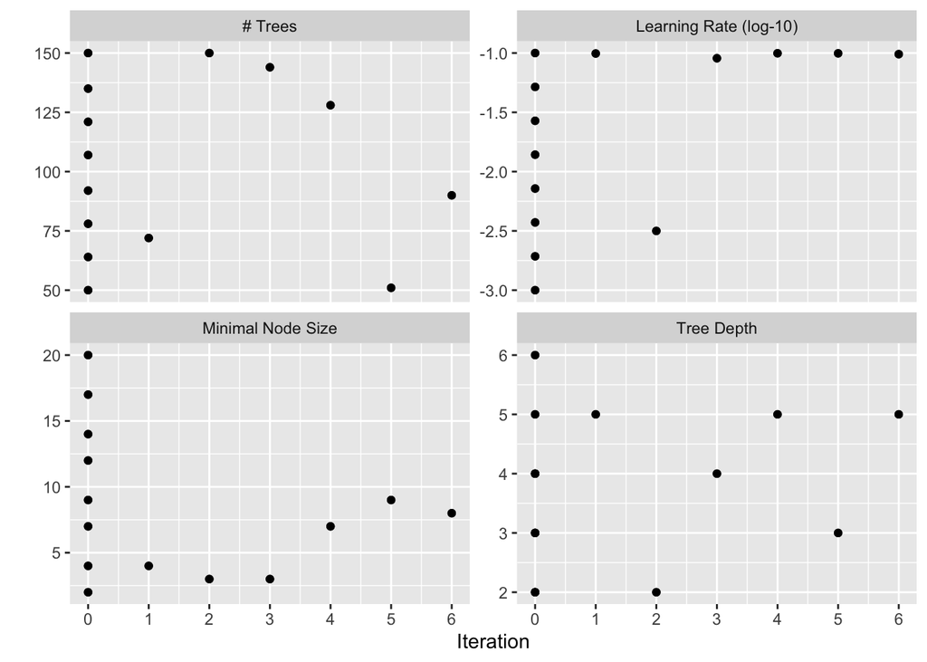

```r
autoplot(ad_bayes, type = "parameters")
```

Sprawdzamy, czy najlepszy wynik z optymalizacji bayesowskiej poprawił najlepszy wynik startowy.

```r
bind_rows(
  show_best(ad_initial, metric = "roc_auc", n = 1) %>%
    mutate(stage = "initial"),
  show_best(ad_bayes, metric = "roc_auc", n = 1) %>%
    mutate(stage = "bayes")
) %>%
  select(stage, trees, tree_depth, learn_rate, min_n, mean, std_err)
```

```
# A tibble: 2 × 7
  stage   trees tree_depth learn_rate min_n  mean std_err
  <chr>   <int>      <int>      <dbl> <int> <dbl>   <dbl>
1 initial   150          3     0.0268     4 0.852 0.0173
2 bayes      90          5     0.0979     8 0.861 0.00985
```

Finalizujemy workflow według `roc_auc`.

```r
best_ad <- select_best(ad_bayes, metric = "roc_auc")
best_ad
```

```
# A tibble: 1 × 5
  trees min_n tree_depth learn_rate .config
  <int> <int>      <int>      <dbl> <chr>
1    90     8          5     0.0979 iter6
```

```r
final_ad_wf <- finalize_workflow(ad_wf, best_ad)
```

Ocena testowa:

```r
set.seed(2026)

ad_last <- last_fit(
  final_ad_wf,
  split = ad_split,
  metrics = metric_set(roc_auc, accuracy)
)

collect_metrics(ad_last)
```

```
# A tibble: 2 × 4
  .metric  .estimator .estimate .config
  <chr>    <chr>          <dbl> <chr>
1 accuracy binary         0.917 pre0_mod0_post0
2 roc_auc  binary         0.983 pre0_mod0_post0
```

Macierz pomyłek:

```r
ad_test_pred <- collect_predictions(ad_last)

ad_conf_mat <- conf_mat(ad_test_pred, truth = Class, estimate = .pred_class)
ad_conf_mat
```

```
          Truth
Prediction Impaired Control
  Impaired       18       2
  Control         5      59
```

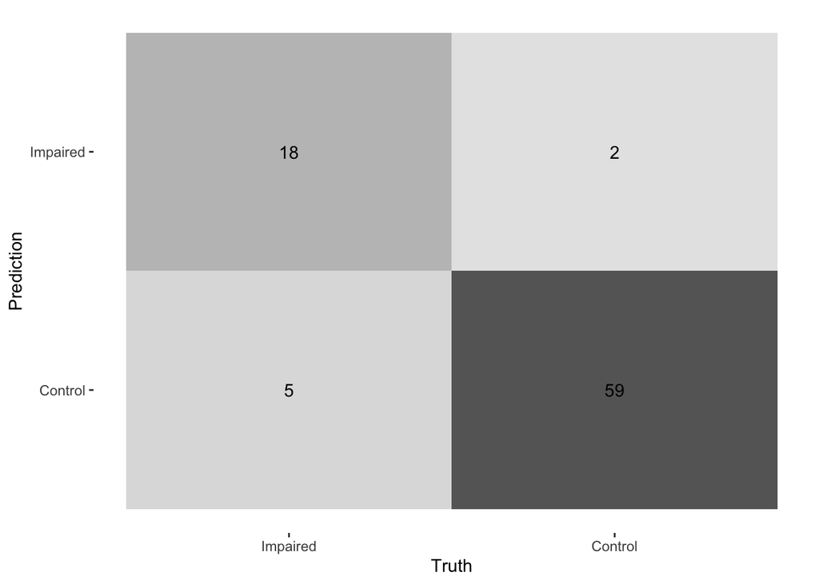

```r
autoplot(ad_conf_mat, type = "heatmap")
```

Jeżeli najlepsza konfiguracja po optymalizacji bayesowskiej ma wyższe średnie `roc_auc` niż najlepszy punkt startowy, iteracyjne wyszukiwanie realnie poprawiło wynik. Wynik testowy należy traktować jako kontrolę, czy poprawa z resamplingu przeniosła się na dane nieużywane w procesie optymalizacji.